# RelationalToE

Desmond Ong

November 13, 2014

# Multi attribution experiment

https://web.stanford.edu/~dco/experiments/v60

Bob spins two wheels (call them wheel A and wheel B).

- Asked how he feels about wheel A
- Asked how he feels about wheel B
- Asked how he feels overall

(For this experiment, I randomized whether A and B were on the left or right, but I always asked about wheel A first, and then about wheel B. Order of asking is the same, but left/right was counterbalanced, so whether Ps were asked about LEFT wheel first or RIGHT wheel first was counterbalanced.)

DVs:

- Happy
- Content
- Relief
- Sad
- Disappointment
- Regret

### Collapsing across all wheels

If we collapse across all wheels (i.e. collapsing left/right, first/second, etc), and just model how Bob feels about that wheel,

- Loss Aversion seems to disappear.

| Emotion (t value in parenthesis) | Main Effect | Coeff on Win | Coeff on PE | Coeff on absPE |
| --- | --- | --- | --- | --- |
| Happy, collapsed across all | 4.5029 (7.9633) | 0.0332 (3.4761) | 0.0409 (3.7878) | -0.0085 (-0.9708) |
| Content, collapsed across all | 4.3666 (7.9043) | 0.0283 (3.0504) | 0.0395 (3.7658) | -0.0071 (-0.839) |
| Relief, collapsed across all | 4.313 (5.0615) | 0.0179 (1.2466) | 0.0522 (3.2215) | -0.0085 (-0.6475) |
| — | — | — | — | — |
| Sad, collapsed across all | 4.0025 (7.168) | -0.0273 (-2.9029) | -0.0249 (-2.3477) | 0.0143 (1.6606) |
| Disapp, collapsed across all | 4.7695 (7.3422) | -0.0293 (-2.6669) | -0.0428 (-3.4577) | 0.0165 (1.6488) |
| Regret, collapsed across all | 3.8534 (7.3527) | -0.021 (-2.3994) | -0.0315 (-3.1784) | 0.0117 (1.464) |

### Analysis on individual wheels

| Emotion (t value in parenthesis) | Main Effect | Coeff on Win | Coeff on PE | Coeff on absPE |
| --- | --- | --- | --- | --- |
| Happy for left wheel, Left wheel | 3.8532 (5.8231) | 0.0316 (3.2446) | 0.0402 (3.6853) | -0.0114 (-1.1229) |
| (coeffs on right wheel) | — | 0.0133 (1.7063) | -0.0114 (-1.145) | 0.0084 (0.8631) |
| Happy for right wheel, Left wheel | 4.3288 (6.9113) | 0.0106 (1.515) | -0.004 (-0.4376) | 0.0043 (0.4608) |
| (coeffs on right wheel) | — | 0.0255 (2.7061) | 0.0492 (4.657) | -0.0156 (-1.6061) |

So judgments seem to affect each other. Let’s look at order effects:

| Emotion (t value in parenthesis) | Main Effect | Coeff on Win | Coeff on PE | Coeff on absPE |
| --- | --- | --- | --- | --- |
| Happy for left wheel, Left wheel | 1.8602 (3.5834) | 0.0819 (6.1893) | -0.0148 (-1.0334) | -0.0291 (-3.1731) |
| firstWheelShownOnRight times (coeffs on left wheel) | 3.3578 (4.5325) | -0.0661 (-4.1572) | 0.0792 (4.8233) | 0.0048 (0.4023) |
| (coeffs on right wheel) | — | 0.0113 (1.229) | -0.0165 (-1.9012) | 0.0266 (3.4582) |
| firstWheelShownOnRight times (coeffs on right wheel) | — | -0.0017 (-0.105) | 0.0063 (0.3745) | -0.03 (-2.5198) |
| — | — | — | — | — |
| Happy for right wheel, Left wheel | 2.4738 (2.939) | 0.0145 (0.9765) | -0.0093 (-0.6633) | 0.015 (1.1354) |
| firstWheelShownOnLeft times (coeffs on left wheel) | 3.055 (2.6513) | -0.0144 (-0.5278) | 0.015 (0.5468) | -0.008 (-0.4047) |
| (coeffs on right wheel) | — | 0.0674 (3.0944) | 0.007 (0.2955) | -0.0362 (-2.4304) |
| firstWheelShownOnLeft times (coeffs on right wheel) | — | -0.0558 (-2.056) | 0.053 (1.9476) | 0.0183 (0.9384) |

### Overall feelings

If first wheel asked is on the right, Left Wheel is weighted more than Right Wheel. (that’s the interactionless coeff on win_1 etc)

If first wheel asked is on the left, Left Wheel is weighted less compared to when it was asked about second. (recency) (interaction sig. for happy, relief, disapp, regret)

but in e3 = e1 + e2, weights are similar for both e1 and e2. (Except for relief; e1 is weighed more)

# Sequential

https://web.stanford.edu/~dco/experiments/v61

### Collapsing across all wheels

If we collapse across all wheels (i.e. collapsing left/right, first/second, etc), and just model how Bob feels about that wheel,

- Loss Aversion seems to disappear.

| Emotion (t value in parenthesis) | Main Effect | Coeff on Win | Coeff on PE | Coeff on absPE |
| --- | --- | --- | --- | --- |
| Happy, collapsed across all | 4.4589 (**7.5942**) | 0.0329 (**3.3068**) | 0.0447 (**3.9999**) | -0.0082 (-0.899) |
| Content, collapsed across all | 4.4199 (**8.3542**) | 0.0291 (**3.267**) | 0.0459 (**4.5746**) | -0.0103 (-1.2556) |
| Relief, collapsed across all | 4.3921 (**5.2885**) | 0.0156 (1.1104) | 0.0643 (**4.0621**) | -0.009 (-0.6955) |
| — | — | — | — | — |
| Sad, collapsed across all | 4.2368 (**8.6375**) | -0.028 (**-3.3903**) | -0.0336 (**-3.6161**) | 0.0168 (**2.2234**) |
| Disapp, collapsed across all | 4.8835 (**8.4432**) | -0.0249 (**-2.5496**) | -0.055 (**-5.0161**) | 0.0147 (1.6484) |
| Regret, collapsed across all | 4.0889 (**8.7267**) | -0.0207 (**-2.6407**) | -0.0339 (**-3.8464**) | 0.0073 (1.018) |

### Analysis on individual wheels

| Emotion (t value in parenthesis) | Main Effect | Coeff on Win | Coeff on PE | Coeff on absPE |
| --- | --- | --- | --- | --- |
| Happy for first wheel, first wheel | 3.8208 (**5.3931**) | 0.0354 (**3.2794**) | 0.0378 (**3.1258**) | -0.0044 (-0.3886) |
| (coeffs on second wheel) | — | 0.0075 (0.9849) | -0.0081 (-0.7836) | 0.0044 (0.4174) |
| Happy for second wheel, coeffs on first wheel | 4.1104 (**5.6987**) | 0.0115 (1.2794) | -0.0094 (-0.8419) | -0.0017 (-0.1579) |
| (coeffs on second wheel) | — | 0.0293 (**2.8043**) | 0.0511 (**4.3531**) | -0.0109 (-0.9839) |
| — | — | — | — | — |
| Content for first wheel, first wheel | 3.4869 (**5.3506**) | 0.0289 (**2.9766**) | 0.0445 (**4.0772**) | -0.0117 (-1.1467) |
| (coeffs on second wheel) | — | 0.0165 (**2.1268**) | -0.0177 (-1.8368) | 0.0081 (0.8432) |
| Content for second wheel, coeffs on first wheel | 3.9829 (**7.0447**) | 0.0183 (**2.5908**) | -0.0124 (-1.4343) | -0.0012 (-0.1428) |
| (coeffs on second wheel) | — | 0.0199 (**2.4019**) | 0.0543 (**5.999**) | -0.0124 (-1.4652) |
| — | — | — | — | — |
| Relief for first wheel, coeffs on first wheel | 3.6206 (**4.1271**) | 0.0104 (0.7865) | 0.0704 (**4.7307**) | -0.0159 (-1.1446) |
| (coeffs on second wheel) | — | 0.0172 (1.7661) | -0.0147 (-1.1421) | 0.0113 (0.8679) |
| Relief for second wheel, coeff on first wheel | 3.5942 (**3.1839**) | 0.0102 (0.6438) | -0.0101 (-0.5521) | 1.8087 × 10<sup>-4</sup> (0.0105) |
| (coeffs on second wheel) | — | 0.0219 (1.4697) | 0.058 (**3.3016**) | -0.0084 (-0.4932) |
| — | — | — | — | — |
| Sad for first wheel, coeffs on first wheel | 4.452 (**7.2016**) | -0.0244 (**-2.6764**) | -0.0366 (**-3.5613**) | 0.0212 (**2.2171**) |
| (coeffs on second wheel) | — | -0.0061 (-0.803) | 0.0092 (0.9978) | -0.0099 (-1.1002) |
| Sad for second wheel, coeff on first wheel | 4.5618 (**7.4313**) | -0.0047 (-0.6064) | 8.9872 × 10<sup>-4</sup> (0.0946) | -0.0015 (-0.1692) |
| (coeffs on second wheel) | — | -0.0293 (**-3.3121**) | -0.0322 (**-3.2892**) | 0.0187 (**2.0282**) |
| — | — | — | — | — |
| Disapp for first wheel, coeffs on first wheel | 5.2287 (**7.1007**) | -0.0195 (-1.8782) | -0.0621 (**-5.2227**) | 0.0235 (**2.0927**) |
| (coeffs on second wheel) | — | -0.0117 (-1.1926) | 0.0128 (1.1337) | -0.0122 (-1.1181) |
| Disapp for second wheel, coeff on first wheel | 5.5698 (**7.6646**) | -0.0132 (-1.3337) | 0.0062 (0.5351) | 0.0048 (0.4403) |
| (coeffs on second wheel) | — | -0.0255 (**-2.5379**) | -0.0509 (**-4.4913**) | 0.0137 (1.2718) |
| — | — | — | — | — |
| Regret for first wheel, first wheel | 4.2509 (**6.7065**) | -0.0179 (-1.9691) | -0.0354 (**-3.4327**) | 0.0113 (1.1736) |
| (coeffs on second wheel) | — | -0.0054 (-0.6533) | 0.0079 (0.827) | -0.0097 (-1.0486) |
| Regret for second wheel, coeff on first wheel | 4.5747 (**8.6835**) | -0.0085 (-1.2572) | 0.0022 (0.2695) | 0.0012 (0.1555) |
| (coeffs on second wheel) | — | -0.0214 (**-2.809**) | -0.0338 (**-4.0826**) | 0.0093 (1.1965) |

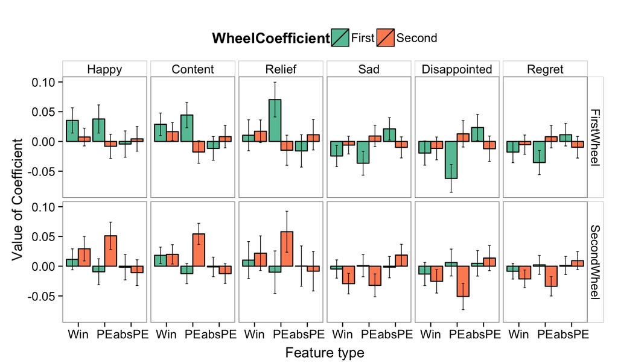

### Overall emotion

If we now look at the overall emotion attributed

| Emotion (t value in parenthesis) | Main Effect | Coeff on Win | Coeff on PE | Coeff on absPE |
| --- | --- | --- | --- | --- |
| Happy overall, coeffs on first wheel | 3.9309 (**8.7447**) | 0.0248 (**4.1856**) | 0.005 (0.7179) | -0.0042 (-0.6336) |
| (coeffs on second wheel) | — | 0.0242 (**3.8289**) | 0.0189 (**2.6836**) | -0.0019 (-0.2907) |
| — | — | — | — | — |
| Content overall, coeffs on first wheel | 3.0237 (**6.682**) | 0.0334 (**5.721**) | -0.0028 (-0.3987) | -0.0017 (-0.2512) |
| (coeffs on second wheel) | — | 0.0257 (**3.946**) | 0.0158 (**2.2304**) | -0.002 (-0.3004) |
| — | — | — | — | — |
| Relief overall, coeffs on first wheel | 2.8017 (**3.8134**) | 0.0265 (**3.1806**) | 0.0013 (0.122) | 0.0035 (0.3215) |
| (coeffs on second wheel) | — | 0.0186 (1.6956) | 0.0268 (**2.2087**) | 0.0025 (0.2164) |
| — | — | — | — | — |
| Sad overall, coeffs on first wheel | 5.4638 (**9.32**) | -0.0235 (**-2.7197**) | -0.0012 (-0.1186) | 0.0069 (0.7586) |
| (coeffs on second wheel) | — | -0.0285 (**-3.975**) | -0.0078 (-0.8983) | 0.0081 (0.948) |
| — | — | — | — | — |
| Regret overall, coeffs on first wheel | 5.4073 (**11.6721**) | -0.0217 (**-3.6636**) | -7.468 × 10<sup>-4</sup> (-0.1049) | 0.0038 (0.5589) |
| (coeffs on second wheel) | — | -0.0249 (**-3.7526**) | -0.0124 (-1.7222) | 0.0047 (0.693) |
| — | — | — | — | — |
| Disapp overall, coeffs on first wheel | 6.5046 (**10.1304**) | -0.0237 (**-3.1156**) | -0.0082 (-0.8428) | 2.5154 × 10<sup>-4</sup> (0.0264) |
| (coeffs on second wheel) | — | -0.0333 (**-3.4909**) | -0.0114 (-1.0854) | 0.0069 (0.6997) |

If we make combined win, PE and absPE variables

| Emotion (t value in parenthesis) | Main Effect | Coeff on Win | Coeff on PE | Coeff on absPE |
| --- | --- | --- | --- | --- |
| Happy overall, combined vars | 3.9529 (**7.9455**) | 0.0244 (**5.713**) | 0.0123 (**2.3892**) | -0.0034 (-0.9074) |
| Content overall, combined vars | 3.0584 (**6.4146**) | 0.0293 (**7.1542**) | 0.007 (1.4189) | -0.0022 (-0.61) |
| Relief overall, combined vars | 2.8575 (**3.861**) | 0.0219 (**3.5662**) | 0.0147 (1.8549) | 0.0031 (0.5196) |
| — | — | — | — | — |
| Sad overall, combined vars | 5.286 (**9.1324**) | -0.0243 (**-4.8842**) | -0.006 (-0.9997) | 0.0075 (1.7284) |
| Regret overall, combined vars | 5.2814 (**10.2731**) | -0.0221 (**-5.0504**) | -0.0079 (-1.479) | 0.0044 (1.1327) |
| Disapp overall, combined vars | 6.2965 (**10.2113**) | -0.0263 (**-5.0345**) | -0.0116 (-1.7801) | 0.0033 (0.6872) |

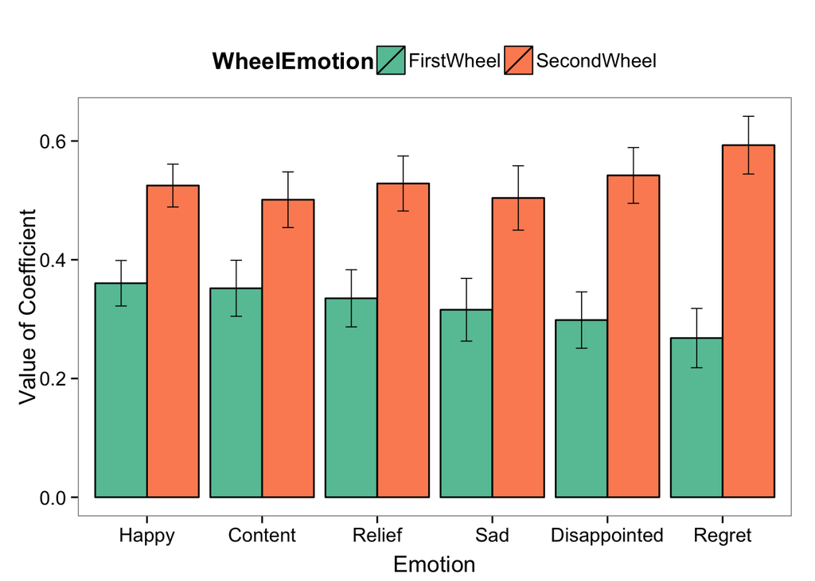

If we now use the emotions from the first two wheels to predict overall emotion

| Emotion (t value in parenthesis) | Main Effect | Coeff on first wheel emotion | Coeff on second wheel emotion |
| --- | --- | --- | --- |
| Happy overall | 1.0407 (**6.7876**) | 0.3605 (**18.4365**) | 0.5249 (**28.5154**) |
| Content overall | 1.1631 (**6.4103**) | 0.3519 (**14.6268**) | 0.5011 (**20.9619**) |
| Relief overall | 0.9286 (**5.2673**) | 0.335 (**13.6301**) | 0.5285 (**22.3463**) |
| Sad overall | 0.4726 (**3.515**) | 0.3158 (**11.731**) | 0.5041 (**18.2218**) |
| Disapp overall | 0.3853 (**2.8135**) | 0.2984 (**12.3287**) | 0.5421 (**22.6348**) |
| Regret overall | 0.3695 (**3.3984**) | 0.2681 (**10.5268**) | 0.593 (**23.898**) |

```
## Data: v61data_melt
## Models:
## wheelModelFullr: Emotion3 ~ (Emotion12) * Emotion + (1 | Emotion) + (1 | spinnerID_1) +
## wheelModelFullr:     (1 | spinnerID_2) + (1 | workerid)
## wheelModelFull: Emotion3 ~ (Emotion12 + Emotion2) * Emotion + (1 | Emotion) +
## wheelModelFull:     (1 | spinnerID_1) + (1 | spinnerID_2) + (1 | workerid)
##                 Df   AIC   BIC logLik deviance Chisq Chi Df Pr(>Chisq)
## wheelModelFullr 17 13267 13374  -6616    13233
## wheelModelFull  23 13001 13146  -6477    12955   278      6     <2e-16 ***
## ---
## Signif. codes:  0 '***' 0.001 '**' 0.01 '*' 0.05 '.' 0.1 ' ' 1
```